# Task 3 Car Purchasing

```python
import numpy as bp
import os
import pandas as pd
import matplotlib.pyplot as plt
%matplotlib inline
from matplotlib import style
import seaborn as sns
```

```python
#import csv file
df = pd.read_csv('car purchasing.csv')
```

## Data cleaning process

```python
#check the data type
df.info()
```

```
<class 'pandas.core.frame.DataFrame'>
RangeIndex: 500 entries, 0 to 499
Data columns (total 10 columns):
 #   Column               Non-Null Count  Dtype
---  ------               --------------  -----
 0   Customer name        500 non-null    object
 1   Customer e-mail      500 non-null    object
 2   Country              500 non-null    object
 3   Gender               500 non-null    object
 4   Age group            500 non-null    object
 5   Age                  500 non-null    int64
 6   Annual Salary        500 non-null    int64
 7   Credit card debit    500 non-null    float64
 8   Net worth            500 non-null    int64
 9   Car Purchase Amount  500 non-null    int64
dtypes: float64(1), int64(4), object(5)
memory usage: 39.2+ KB
```

```python
#check the null values
pd.isnull(df).sum()
```

```
Customer name          0
Customer e-mail        0
Country                0
Gender                 0
Age group              0
Age                    0
Annual Salary          0
Credit card debit      0
Net worth              0
Car Purchase Amount    0
dtype: int64
```

```python
df.shape
```

[output not shown]

```python
#change from float to int
df['Credit card debit'] = df['Credit card debit'].astype('int')
```

```python
df.columns
```

```
Index(['Customer name', 'Customer e-mail', 'Country', 'Gender', 'Age group',
       'Age', 'Annual Salary', 'Credit card debit', 'Net worth',
       'Car Purchase Amount'],
      dtype='object')
```

```python
#Drop duplicate values
df.drop_duplicates(subset = 'Customer e-mail', keep = "first").head(2)
```

[output not shown]

## Exploratory Data Analysis

```python
df.columns
```

[output not shown]

```python
import warnings
warnings.filterwarnings('ignore')
```

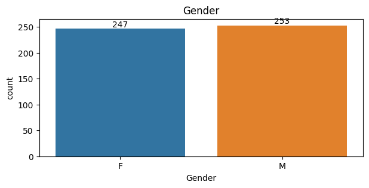

```python
plt.figure(figsize = (7,3))
ax = sns.countplot(x = 'Gender', data = df)

for bars in ax. containers:
    ax.bar_label(bars)
plt.title('Gender')
plt.show()
```

### The count of the female is around 247 and male's count is 253.

```python
print(df['Car Purchase Amount'].max())
df['Customer name'] [df['Car Purchase Amount'].idxmax()]
```

```
80000
```

```
'Cameron, Kimberley P.'
```

```python
print(df['Car Purchase Amount'].max())
df['Age'] [df['Car Purchase Amount'].idxmax()]
```

```
80000
```

```
55
```

```python
print(df['Car Purchase Amount'].max())
df['Net worth'] [df['Car Purchase Amount'].idxmax()]
```

```
80000
```

```
1000000
```

```python
print(df['Car Purchase Amount'].max())
df['Annual Salary'] [df['Car Purchase Amount'].idxmax()]
```

```
80000
```

```
83334
```

### The highest amount for the car was paid by Cameron, Kimberley P. a Male around the age of 55 from Namibia. His net worth is around 1000000 and his annual salary is 83334.

```python
df[(df.Age <= 19)]
```

|  | Customer name | Customer e-mail | Country | Gender | Age | Annual Salary | Credit card debit | Net worth | Car Purchase Amount |
| --- | --- | --- | --- | --- | --- | --- | --- | --- | --- |

```python
df[(df.Age <= 50)]
```

|  | Customer name | Customer e-mail | Country | Gender | Age | Annual Salary | Credit card debit | Net worth | Car Purchase Amount |
| --- | --- | --- | --- | --- | --- | --- | --- | --- | --- |
| 0 | Martina Avila | cubilia.Curae.Phasellus@quisaccumsanconvallis.edu | Bulgaria | F | 42 | 62812 | 11609 | 238961 | 35322 |
| 1 | Harlan Barnes | eu.dolor@diam.co.uk | Belize | F | 41 | 66647 | 9572 | 530974 | 45116 |
| 2 | Naomi Rodriquez | vulputate.mauris.sagittis@ametconsectetueradip... | Algeria | M | 43 | 53799 | 11160 | 638467 | 42926 |
| 6 | Griffin Rivera | vehicula@at.co.uk | Syria | M | 47 | 39815 | 5958 | 326373 | 28926 |
| 7 | Orli Casey | nunc.est.mollis@Suspendissetristiqueneque.co.uk | Czech Republic | M | 50 | 51752 | 10985 | 629312 | 47435 |
| ... | ... | ... | ... | ... | ... | ... | ... | ... | ... |
| 491 | Merrill | dolor.sit@turpisIn.com | Egypt | M | 50 | 78518 | 10072 | 294506 | 52786 |
| 493 | Winter | egestas.urna.justo@maurissagittis.edu | Wallis and Futuna | F | 43 | 77665 | 13308 | 349589 | 47761 |
| 495 | Walter | ligula@Cumsociis.ca | Nepal | F | 41 | 71942 | 6995 | 541670 | 48902 |
| 496 | Vanna | Cum.sociis.natoque@Sedmolestie.edu | Zimbabwe | M | 38 | 56039 | 12301 | 360419 | 31492 |
| 499 | Marla | Camaron.marla@hotmail.com | marlal | M | 47 | 61371 | 9391 | 462946 | 45108 |

344 rows × 9 columns

```python
df[(df.Age >= 50)]
```

|  | Customer name | Customer e-mail | Country | Gender | Age | Annual Salary | Credit card debit | Net worth | Car Purchase Amount |
| --- | --- | --- | --- | --- | --- | --- | --- | --- | --- |
| 3 | Jade Cunningham | malesuada@dignissim.com | Cook Islands | M | 58 | 79370 | 14426 | 548599 | 67423 |
| 4 | Cedric Leach | felis.ullamcorper.viverra@egetmollislectus.net | Brazil | M | 57 | 59729 | 5358 | 560304 | 55916 |
| 5 | Carla Hester | mi@Aliquamerat.edu | Liberia | M | 57 | 68500 | 14179 | 428485 | 56612 |
| 7 | Orli Casey | nunc.est.mollis@Suspendissetristiqueneque.co.uk | Czech Republic | M | 50 | 51752 | 10985 | 629312 | 47435 |
| 10 | Jerome Rowe | ipsum.cursus@dui.org | Sint Maarten | M | 50 | 73349 | 8270 | 612739 | 59046 |
| ... | ... | ... | ... | ... | ... | ... | ... | ... | ... |
| 491 | Merrill | dolor.sit@turpisIn.com | Egypt | M | 50 | 78518 | 10072 | 294506 | 52786 |
| 492 | Nolan | Donec.at@neccursus.co.uk | Latvia | F | 55 | 72425 | 9831 | 523681 | 60118 |
| 494 | Rigel | egestas.blandit.Nam@semvitaealiquam.com | Sao Tome and Principe | F | 52 | 77346 | 6736 | 665099 | 64189 |
| 497 | Pearl | penatibus.et@massanonante.com | Philippines | M | 54 | 68889 | 10611 | 764531 | 64148 |
| 498 | Nell | Quisque.varius@arcuVivamussit.net | Botswana | M | 59 | 49812 | 14013 | 337827 | 45443 |

175 rows × 9 columns

```python
print(df['Car Purchase Amount'].min())
df['Customer name'] [df['Car Purchase Amount'].idxmin()]
```

```
9000
```

```
'Tatyana'
```

### Overall the cheapest price of car is only 9000 purchased by Tatyana whose age is 25 and his annual salary is 45093.

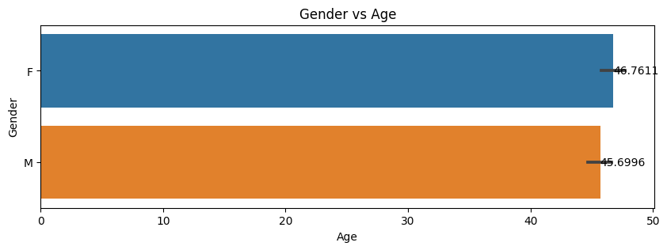

```python
plt.figure(figsize = (10,3))
ax = sns.barplot(x = 'Age', y = 'Gender', data = df)
for bars in ax.containers:
    ax.bar_label(bars)
plt.title('Gender vs Age')
plt.show()
```

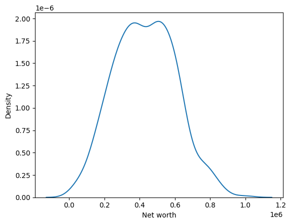

```python
sns.kdeplot(df['Net worth'])
```

```python
df.groupby(['Gender'], as_index=False)['Car Purchase Amount'].sum().sort_values(by='Car Purchase Amount', ascending=False)
```

|  | Gender | Car Purchase Amount |
| --- | --- | --- |
| 0 | F | 11098602 |
| 1 | M | 11006542 |

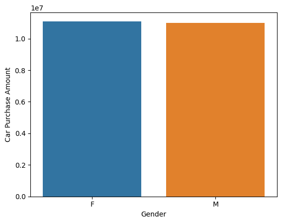

```python
dp=df.groupby(['Gender'], as_index=False)['Car Purchase Amount'].sum().sort_values(by='Car Purchase Amount', ascending=False)
sns.barplot(x= 'Gender', y= 'Car Purchase Amount', data = dp)
```

```python
df[['Age', 'Car Purchase Amount', 'Net worth', 'Customer name']].describe()
```

|  | Age | Car Purchase Amount | Net worth |
| --- | --- | --- | --- |
| count | 500.000000 | 500.000000 | 500.000000 |
| mean | 46.224000 | 44210.288000 | 431475.700000 |
| std | 7.990339 | 10773.182576 | 173536.758223 |
| min | 20.000000 | 9000.000000 | 20000.000000 |
| 25% | 41.000000 | 37630.500000 | 299824.000000 |
| 50% | 46.000000 | 43998.500000 | 426750.000000 |
| 75% | 52.000000 | 51255.500000 | 557324.500000 |
| max | 70.000000 | 80000.000000 | 1000000.000000 |

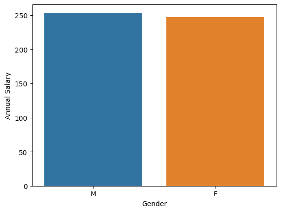

```python
dp=df.groupby(['Gender'], as_index=False)['Annual Salary'].count().sort_values(by='Annual Salary', ascending=False)
sns.barplot(x= 'Gender', y= 'Annual Salary', data = dp)
```

```python
dp=df.groupby(['Country'], as_index=False)['Car Purchase Amount'].count().sort_values(by='Country', ascending=False)
sns.barplot(x= 'Car Purchase Amount', y= 'Country', data = dp)

sns.set(rc={'figure.figsize':(50,200)})
sns.barplot(data = dp, x = 'Car Purchase Amount', y= 'Country')
```

[figure not shown]

```python
#Top 5 cars with highest amount
df.nlargest(5, columns=['Car Purchase Amount'], keep='first')
```

|  | Customer name | Customer e-mail | Country | Gender | Age | Annual Salary | Credit card debit | Net worth | Car Purchase Amount |
| --- | --- | --- | --- | --- | --- | --- | --- | --- | --- |
| 315 | Cameron, Kimberley P. | nec.tellus@lacinia.co.uk | Namibia | M | 55 | 83334 | 9874 | 1000000 | 80000 |
| 289 | Madeson R. Salinas | Cum.sociis.natoque@acnullaIn.edu | Bonaire, Sint Eustatius and Saba | F | 48 | 86565 | 13701 | 819002 | 70879 |
| 400 | Melodie | facilisi.Sed@tortordictum.com | Korea, South | M | 62 | 66655 | 8001 | 805076 | 70599 |
| 470 | Diana | purus.ac.tellus@parturientmontesnascetur.org | Guadeloupe | F | 60 | 81566 | 9072 | 544292 | 69670 |
| 45 | Quincy Bell | in@Duisgravida.co.uk | Timor-Leste | F | 55 | 70787 | 10155 | 853914 | 68926 |

```python
#Top 5 cars
Top5_cars=df.nlargest(5,'Car Purchase Amount')[['Customer name', 'Country', 'Age', 'Gender','Annual Salary']]\
.set_index('Annual Salary')
```

```python
Top5_cars
```

| Annual Salary | Customer name | Country | Age | Gender |
| --- | --- | --- | --- | --- |
| 83334 | Cameron, Kimberley P. | Namibia | 55 | M |
| 86565 | Madeson R. Salinas | Bonaire, Sint Eustatius and Saba | 48 | F |
| 66655 | Melodie | Korea, South | 62 | M |
| 81566 | Diana | Guadeloupe | 60 | F |
| 70787 | Quincy Bell | Timor-Leste | 55 | F |

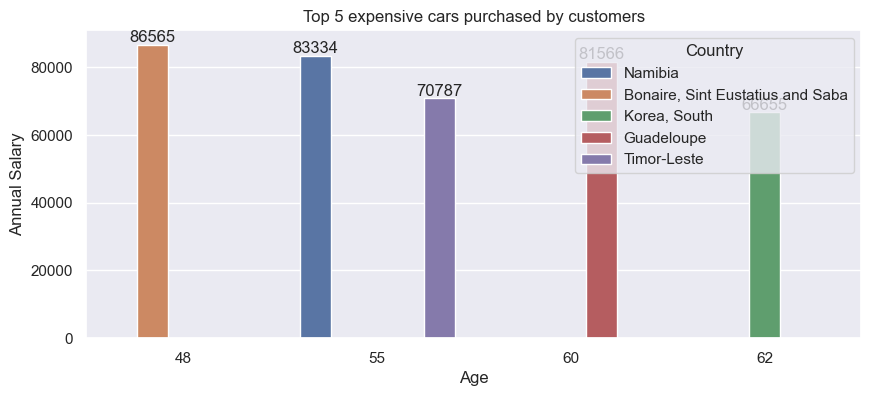

```python
plt.figure(figsize = (10,4))
ax = sns.barplot(x='Age', y=Top5_cars.index,data=Top5_cars, hue='Country')
for bars in ax. containers:
    ax.bar_label(bars)
plt.title('Top 5 expensive cars purchased by customers')
plt.show()
```

[figure not shown]

```python
plt.figure(figsize = (10,4))
ax = sns.barplot(x='Age', y=Top5_cars.index,data=Top5_cars, hue='Gender')
for bars in ax. containers:
    ax.bar_label(bars)
plt.title('Top 5 expensive cars purchased by customers's details ')
plt.show()
```

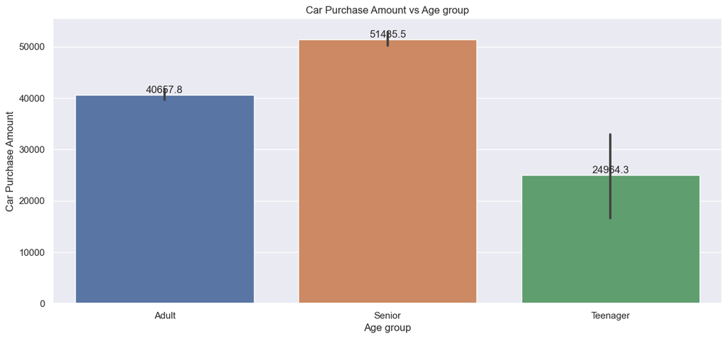

```python
plt.figure(figsize = (14,6))
ax = sns.barplot(x = 'Age group', y = 'Car Purchase Amount', data = df)
for bars in ax.containers:
    ax.bar_label(bars)
plt.title('Car Purchase Amount vs Age group')
plt.show()
```

### The maximum amount spent by senior age group customers whoes age is equal to or greater than 50.

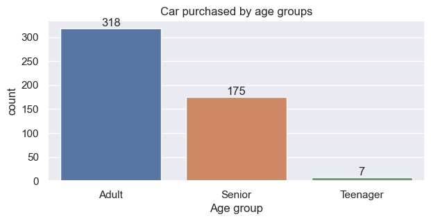

```python
plt.figure(figsize = (7,3))
ax = sns.countplot(x = 'Age group', data = df)

for bars in ax. containers:
    ax.bar_label(bars)
plt.title('Car purchased by age groups')
plt.show()
```

### The maximum amount spent by senior age group customers there's age is equal to or greater than 50.

### The cars purchased by adults (30 to 49 age) are more than seniors (>=50 age) or teenagers (<=30 age).

### Graphically presented the top 5 expensive cars details.